# Análisis de la relación entre el uso de recursos tecnológicos y la productividad de los estudiantes de UTEC durante el ciclo 2023-1

Universidad de Ingeniería y Tecnología

2023-1

# Año del Fortalecimiento de la Soberanía Nacional

# AVANCE 1-PG 1 ORAL

## Curso:

Estadística y Probabilidades

## Docente:

Brigida Coromoto, Molina Carabaño

## Integrantes:

| Apellidos y Nombres | Código | Participación |
| --- | --- | --- |
| Torres Castañeda, Rodrigo Alonso |  | 100% |
| Maravi Romero, Javier Anthony | 202120352 | 100% |
| Aldude Hidalgo, Mary Cielo | 202120063 | 100% |
| Artca Reyna, Juan Adolfo | 201910356 | 100% |
| Guerrero Alejos, Sebastian Nicolas | 202210155 | 100% |

## TEMA

Análisis de la relación entre el uso de recursos tecnológicos (software y hardware) y la productividad de los estudiantes de UTEC durante el ciclo 2023-1.

## RELEVANCIA

El análisis de la relación entre el uso de recursos tecnológicos (software y hardware) y la productividad de los estudiantes es un tema relevante en la educación actual. Investigar esta relación permite mejorar la enseñanza y el aprendizaje al identificar las mejores prácticas para integrar la tecnología, garantizar un acceso equitativo, optimizar los recursos educativos y preparar a los estudiantes para el mundo digital. Comprender cómo la tecnología afecta el rendimiento estudiantil es fundamental para promover un entorno educativo más efectivo y equipar a los estudiantes con habilidades digitales necesarias en el mundo actual.

## OBJETIVOS

### GENERAL

Determinar la relación entre el uso de recursos tecnológicos y la productividad de los estudiantes de UTEC durante el ciclo 2023-1.

### ESPECÍFICOS

1. Identificar los recursos tecnológicos (software y hardware) utilizados por los estudiantes de UTEC durante el ciclo 2023-1.
2. Determinar la frecuencia de uso de los recursos tecnológicos (software y hardware) por parte de los estudiantes de UTEC durante el ciclo 2023-1.
3. Evaluar la productividad de los estudiantes de UTEC relacionada con el uso de recursos tecnológicos mediante la revisión de su rendimiento académico durante el ciclo 2023-1. También evaluarlo por género (Hombre y Mujer).
4. Evaluar la productividad de los estudiantes de UTEC relacionada por género con el uso de recursos tecnológicos mediante la revisión de su rendimiento académico durante el ciclo 2023-1.
5. Identificar el grado de recomendación de los estudiantes de UTEC sobre el uso de recursos tecnológicos para su desempeño académico.

## POBLACIÓN

Estudiantes de UTEC que están cursando el ciclo 2023-1.

## MUESTRA

Todos los estudiantes de la universidad que tengan entre 16 y 32 años, nuestro tamaño de muestra es de 200.

## MUESTREO

Encuesta: Muestreo no probabilístico a conveniencia.

## VARIABLES

[output not shown]

## Librería

```r
if(!require(readr)){install.packages('readr')}
if(!require(dplyr)){install.packages('dplyr')}
```

```r
if(!require(ggplot2)){install.packages('ggplot2')}
if(!require(tidyverse)){install.packages('tidyverse')}
if(!require(RColorBrewer)){install.packages('RColorBrewer')}
if(!require(plotrix)){install.packages('plotrix')}
if(!require(viridis)){install.packages('viridis')}
library(readr)
library(dplyr)
library(tidyverse)
library(viridis)
library(ggplot2)
library(RColorBrewer)
library(plotrix)
```

## Leer el archivo

```r
DF <- read_csv("CBdatos4.csv")
View(DF)
```

## Resumen

```r
str(DF)
```

```
## spc_tbl_ [241 × 20] (S3: spec_tbl_df/tbl_df/tbl/data.frame)
##  $ Marca temporal                                                                                                                                              : chr [1:241] "03/05/2023 13:53:19" "04/05/2023 9:33:34" "04/05/2023 9:44:28" "04/05/2023 9:55:11" ...
##  $ Selecciona tu sexo                                                                                                                                          : chr [1:241] "Masculino" "Masculino" "Masculino" "Femenino" ...
##  $ Edad en años (Ejemplo: 19)                                                                                                                                  : num [1:241] 18 19 19 20 19 19 18 21 18 21 ...
##  $ ¿En qué ciclo de te encuentras?                                                                                                                             : chr [1:241] "3" "4" "4" "4" ...
##  $ Indicar cual es el recurso tecnológico que más te ayuda académicamente                                                                                      : chr [1:241] "Laptop" "Laptop" "No uso activamente recursos tecnologicos con fines académicos" "No uso activamente recursos tecnologicos …
##  $ Cuantos dispositivos tecnológicos electrónicos dispones para fines de estudio ?                                                                             : num [1:241] 3 2 0 20 3 0 2 -1 3 0 ...
##  $ ¿En qué ciclo lo adquiriste?                                                                                                                                : chr [1:241] "2" "4" "4" "1" ...
##  $ De esas horas de estudio, ¿cuántas se ven acompañadas de recursos tecnológicos aproximadamente?                                                             : num [1:241] 2 10 24 16 5 5 8 5 10 16 ...
##  $ En una escala del 1 al 10, ¿Cuánto consideras que incluir recursos tecnológicos es beneficioso para el rendimiento académico?                               : num [1:241] 9 6 9 8 6 10 10 6 8 8 ...
##  $ ¿Cuál consideras el grupo de cursos donde mejor aprovechaste los recursos tecnológicos?                                                                     : chr [1:241] "Ciencias Generales" "Otros" "Ciencias Generales" "Cursos de carrera" ...
##  $ De acuerdo con ese grupo ¿cuál consideras el curso donde se puede aprovecha mejor el uso de recursos  tecnológicos? (Todo en mayúscula y el nombre completo): chr [1:241] "Ecuaciones diferenciales" "GENERALES" "TERMODINÁMICA" "GEOMETRÍA DESCRIPTIVA" ...
##  $ ¿Cuántas horas aproximadas dispones de uso de internet diariamente?(libre)                                                                                  : num [1:241] 4 24 14 24 15 24 24 24 20 79 ...
##  $ Empleas activamente algún recurso de H                                                                                                                      : chr [1:241] "Sí" "Sí" "No" "No" ...
##  $ ¿Aproximadamente cuantas horas le dedicas semanalmente al estudio?                                                                                          : num [1:241] 33 35 39 40 35 40 37 40 35 42 ...
##  $ ¿Cuál es tu promedio ponderado previo a ese ciclo que?                                                                                                      : num [1:241] 12.3 14.2 15.2 16.5 13.3 ...
##  $ ¿Cuál era tu promedio ponderado posterior al empleo de dicho recurso tecnológico?                                                                           : num [1:241] 15.9 15.4 16.6 16.7 15.3 ...
##  $ ¿Empleas activamente aplicaciones de software para el estudio de tus cursos?                                                                                : chr [1:241] "Sí" "Sí" "Sí, pero no activamente" "Sí, pero no activamente" ...
##  $ Que carrera estudias?                                                                                                                                       : chr [1:241] "Bioingeniería" "Ingeniería Civil" "Ingeniería Civil" "Ingeniería Civil" ...
##  $ ¿Qué tipo de aplicaciones más empleas?                                                                                                                      : chr [1:241] "Inteligencias Artificiales (ChatGPT. Youchat. etc.)" "Aplicaciones de texto y notas(word, outlook, etc.)" "Aplicaciones de …
##  $ ¿Cuántos días estudias por semana?                                                                                                                          : num [1:241] 6 7 6 6 6 5 6 5 7 7 ...
##  - attr(*, "spec")=
##   .. cols(
##   ..   `Marca temporal` = col_character(),
##   ..   `Selecciona tu sexo` = col_character(),
##   ..   `Edad en años (Ejemplo: 19)` = col_double(),
##   ..   `¿En qué ciclo de te encuentras?` = col_character(),
##   ..   `Indicar cual es el recurso tecnológico que más te ayuda académicamente` = col_character(),
##   ..   `Cuantos dispositivos tecnológicos electrónicos dispones para fines de estudio ?` = col_double(),
##   ..   `¿En qué ciclo lo adquiriste?` = col_character(),
```

[output cut: 15 more lines]

### Cambiar los nombres de las variables

```r
DF  %>% rename(Marca = "Marca temporal", Sexo = "Selecciona tu sexo", Edad= "Edad en años (Ejemplo: 19)",Ciclo_actual= "¿En qué ciclo de te encuentras?",Recurso_Tecnologico= 'Indicar cual es el recurso tecnológico que más te ayuda académicamente',Dispositivos='Cuantos dispositivos tecnológicos electrónicos dispones para fines de estudio ?', Ciclo_adquirido='¿En qué ciclo lo adquiriste?', Horas_semanales = '¿Aproximadamente cuantas horas le dedicas semanalmente al estudio?',acompañado ="De esas horas de estudio, ¿cuántas se ven acompañadas de recursos tecnológicos aproximadamente?",escala="En una escala del 1 al 10, ¿Cuánto consideras que incluir recursos tecnológicos es beneficioso para el rendimiento académico?",curso ="¿Cuál consideras el grupo de cursos donde mejor aprovechaste los recursos tecnológicos?",cursoEspecifico ="De acuerdo con ese grupo ¿cuál consideras el curso donde se puede aprovecha mejor el uso de recursos  tecnológicos? (Todo en mayúscula y el nombre completo)",Internet="¿Cuántas horas aproximadas dispones de uso de internet diariamente?(libre)",PromedioAntes ="¿Cuál es tu promedio ponderado previo a ese ciclo que?",PromedioDespues="¿Cuál era tu promedio ponderado posterior al empleo de dicho recurso tecnológico?",UsoHardware="Empleas activamente algún recurso de H",UsoSoftware="¿Empleas activamente aplicaciones de software para el estudio de tus cursos?",carrera="Que carrera estudias?",aplicaciones="¿Qué tipo de aplicaciones más empleas?",DiasSemanal="¿Cuántos días estudias por semana?")  -> DF
```

### Eliminamos variables irrelevantes

Marca temporal

```r
DF <- select(DF,-1)
```

Acompañado

```r
DF <- select(DF,-7)
```

Curso Especifico

```r
DF <- select(DF,-9)
```

Internet

```r
DF <- select(DF,-9)
```

#### Volvemos a ver el resumen

```r
summary(DF)
```

```
##      Sexo                Edad      Ciclo_actual       Recurso_Tecnologico
##  Length:241         Min.   : 0.0   Length:241         Length:241
##  Class :character   1st Qu.:18.0   Class :character   Class :character
##  Mode  :character   Median :19.0   Mode  :character   Mode  :character
##                     Mean   :19.4
##                     3rd Qu.:20.0
##                     Max.   :39.0
##
##   Dispositivos    Ciclo_adquirido        escala          curso
##  Min.   :-5.000   Length:241         Min.   : 1.000   Length:241
##  1st Qu.: 1.000   Class :character   1st Qu.: 7.000   Class :character
##  Median : 2.000   Mode  :character   Median : 8.000   Mode  :character
##  Mean   : 2.602                      Mean   : 8.297
##  3rd Qu.: 3.000                      3rd Qu.:10.000
##  Max.   :21.000                      Max.   :10.000
##                                      NA's   :2
##  UsoHardware        Horas_semanales  PromedioAntes   PromedioDespues
##  Length:241         Min.   :  3.00   Min.   :10.38   Min.   : 3.84
##  Class :character   1st Qu.: 34.00   1st Qu.:13.32   1st Qu.:13.54
##  Mode  :character   Median : 35.00   Median :14.39   Median :15.24
##                     Mean   : 35.45   Mean   :14.56   Mean   :14.89
##                     3rd Qu.: 38.00   3rd Qu.:16.35   3rd Qu.:16.41
##                     Max.   :100.00   Max.   :18.87   Max.   :19.35
##
##  UsoSoftware          carrera          aplicaciones        DiasSemanal
##  Length:241         Length:241         Length:241         Min.   :1.00
##  Class :character   Class :character   Class :character   1st Qu.:5.00
##  Mode  :character   Mode  :character   Mode  :character   Median :6.00
##                                                           Mean   :5.66
##                                                           3rd Qu.:7.00
##                                                           Max.   :8.00
##
```

## Metodología de Limpieza de datos

1. Identificar y manejar valores faltantes: Se pueden aplicar técnicas como la imputación de valores o la eliminación de registros con valores faltantes.
2. Corregir errores de formato: Nos aseguramos de que los datos estén en el formato correcto, como fechas, números o categorías.
3. Aplicar las restricciones, condiciones y consideraciones presentados en la tabla de variables para cada una de ellas, respectivamente.
4. Tratar valores atípicos: Examinar los valores extremos y decidir si se deben eliminar, corregir o dejar como están, según el contexto.
5. Estandarizar variables: Alinear las variables en términos de unidades, escalas o formatos para facilitar el análisis.
6. Verificar consistencia y validez: Comprobar la coherencia y validez de los datos en relación con las reglas establecidas o el dominio del problema.

#### Buscamos NA´s

Observaciones incompletas

```r
sum(!complete.cases(DF))
```

```
## [1] 3
```

Datos faltantes

```r
sum(is.na(DF))
```

```
## [1] 6
```

## Limpieza de variables

### Edad

```r
summary(DF$Edad)
```

```
##    Min. 1st Qu.  Median    Mean 3rd Qu.    Max.
##     0.0    18.0    19.0    19.4    20.0    39.0
```

Gráfico de dispersión de las edades de nuestros encuestados:

-Visualmente se puede apreciar ciertos valores atípicos los cuales discutiremos más adelante.

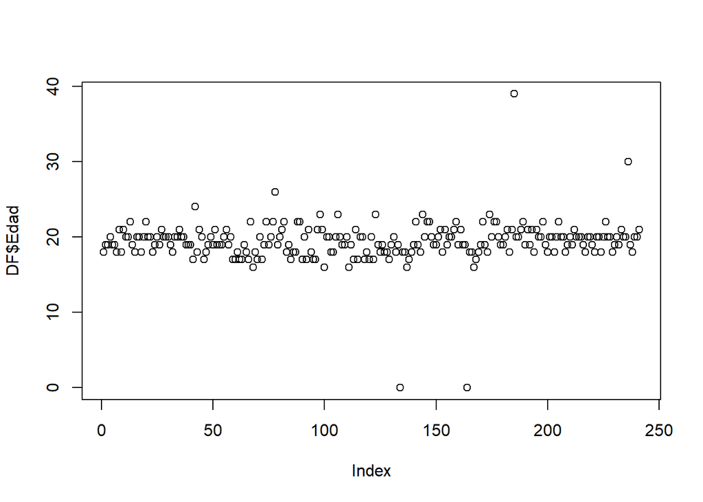

```r
plot(DF$Edad)
```

Identificamos la cantidad de valores que no se encuentran dentro de nuestro rango de interés para edad(De 16 a 32 años), observamos lo siguiente:

-Solo dos personas se encuentra por debajo de nuestro rango de interés.

-Solo una persona se encuentra por encima de nuestro rango de interés.

```r
which(DF$Edad < 16)
```

```
## [1] 134 164
```

```r
which(DF$Edad > 32)
```

```
## [1] 185
```

Los valores de edad fuera de nuestro rango de interés los clasificamos como NA para posteriormente ser eliminados. Esto fue considerando el rango de edad habitual de los jóvenes universitarios.

```r
DF$Edad[DF$Edad<16] <-NA
DF$Edad[DF$Edad>32] <-NA
```

Hacemos lectura a la variable edad, obteniendo el siguiente resumen definitivo:

-La edad promedio de nuestros encuestados fue de 19 años.

-La edad mínima fue de 16 años y la máxima fue de 30 años.

```r
summary(DF$Edad)
```

```
##    Min. 1st Qu.  Median    Mean 3rd Qu.    Max.    NA's
##   16.00   18.00   19.00   19.48   20.00   30.00       3
```

### Cantidad de Dispositivos Tecnológicos para uso académico

```r
summary(DF$Dispositivos)
```

```
##    Min. 1st Qu.  Median    Mean 3rd Qu.    Max.
##  -5.000   1.000   2.000   2.602   3.000  21.000
```

Gráfico de dispersión de la cantidad de dispositivos tecnológicos usado para fines académicos de acuerdo a lo encuestado:

-Visualmente se puede apreciar que la mayoría cuenta entre 0 y 5 dispositivos tecnológicos.

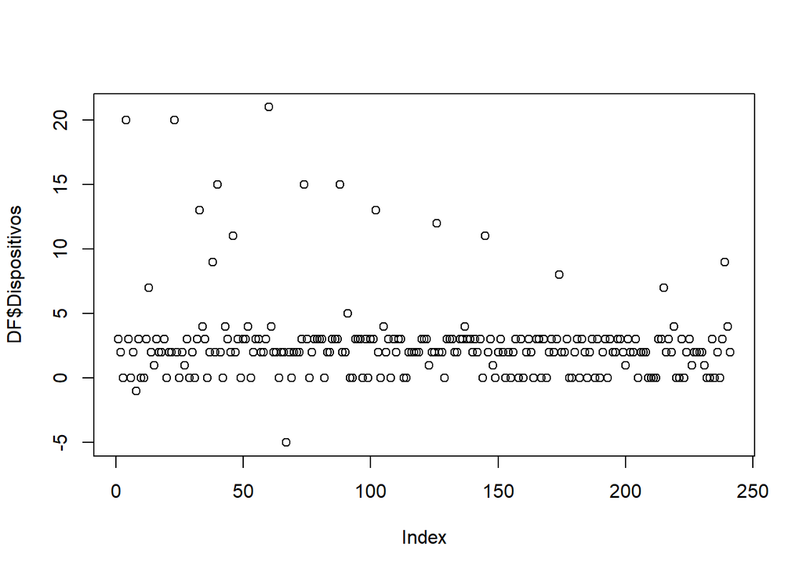

```r
plot(DF$Dispositivos)
```

Las cantidades de dispositivo fuera de nuestro rango de interés los clasificamos como NA para posteriormente ser eliminados. Esto fue considerando un rango razonable justificable de cantidad de dispositivos que podría usar un estudiante.

```r
DF$Dispositivos[DF$Dispositivos<0] <-NA
DF$Dispositivos[DF$Dispositivos>10] <-NA
```

Hacemos lectura a la variable edad, obteniendo el siguiente resumen definitivo:

-La cantidad de dispositivos promedio de nuestros encuestados fue de 2.

-La cantidad mínima fue de 0 y la máxima fue de 9

```r
summary(DF$Dispositivos)
```

```
##    Min. 1st Qu.  Median    Mean 3rd Qu.    Max.    NA's
##   0.000   1.000   2.000   2.048   3.000   9.000      13
```

### Horas Semanales

```r
summary(DF$Horas_semanales)
```

```
##    Min. 1st Qu.  Median    Mean 3rd Qu.    Max.
##    3.00   34.00   35.00   35.45   38.00  100.00
```

Gráfico de dispersión de la cantidad de horas durante la semana dedicadas ara fines académicos de acuerdo a lo encuestado:

-Visualmente se puede apreciar que la mayoría cuenta entre 20 y 45 horas a la semana.

-Se identifica un valor muy por encima de la media.

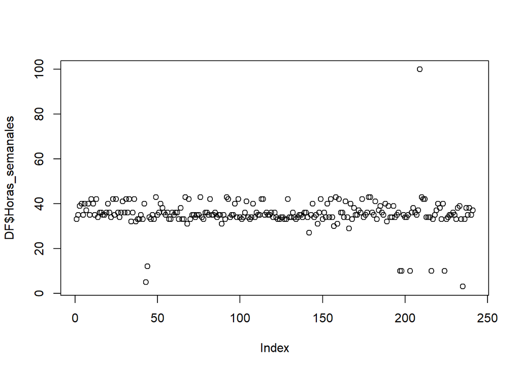

```r
plot(DF$Horas_semanales)
```

Los valores de edad fuera de nuestro rango de interés los clasificamos como NA para posteriormente ser eliminados. Esto fue considerando una cantidad de horas habitual dedicada al estudio por jóvenes universitarios. Por lo que consideramos un rango razonable entre de 20 y 60 horas semanales.

```r
DF$Horas_semanales[DF$Horas_semanales<20] <-NA
DF$Horas_semanales[DF$Horas_semanales>60] <-NA
```

Hacemos lectura a la cantidad de horas semanales dedicadas al estudio, obteniendo el siguiente resumen definitivo:

-La cantidad de horas promedio de nuestros encuestados fue de 35.

-La cantidad mínima fue de 27 horas y la máxima fue de 43 años.

```r
summary(DF$Horas_semanales)
```

```
##    Min. 1st Qu.  Median    Mean 3rd Qu.    Max.    NA's
##   27.00   34.00   35.00   36.09   38.00   43.00       9
```

### Promedios

#### Promedio anterior a adquirir el recurso tecnológico

Para este apartado hemos considerado como el ciclo anterior inmediato al ciclo donde adquirieron dicho recurso(Tablet, Laptop, etc).

```r
summary(DF$PromedioAntes)
```

```
##    Min. 1st Qu.  Median    Mean 3rd Qu.    Max.
##   10.38   13.32   14.39   14.56   16.35   18.87
```

Gráfico de dispersión de los promedios antes de adquirir el recurso tecnológico que más ha ayudado, de acuerdo a lo encuestado:

-No se identifican valores que estén fuera del rango permisible, considerando de 0 a 20 de promedio.

-Esta variable acepta 2 decimales. Asimismo, se le pidió a los encuestados que respondan con estos 2 decimales, ya que el la cantidad de decimales con las que trabaja UTEC al reportar los promedios de sus estudiantes..

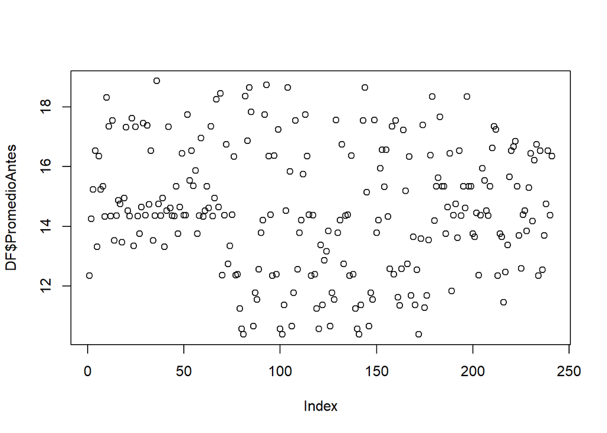

```r
plot(DF$PromedioAntes)
```

Los promedio fuera de nuestro rango de interés los clasificamos como NA para posteriormente ser eliminados. Esto fue considerando un promedio habitual de UTEC, por ejemplo, no se consideró el 20 como promedio.

```r
DF$PromedioAntes[DF$PromedioAntes<8] <-NA
DF$PromedioAntes[DF$PromedioAntes>19] <-NA
```

Hacemos lectura de los promedios antes de adquirir el dispositivo tecnológico que más los ha ayudado en su desempeño académico, obteniendo el siguiente resumen definitivo:

```r
summary(DF$PromedioAntes)
```

```
##    Min. 1st Qu.  Median    Mean 3rd Qu.    Max.
##   10.38   13.32   14.39   14.56   16.35   18.87
```

#### Promedio Después

```r
summary(DF$PromedioDespues)
```

```
##    Min. 1st Qu.  Median    Mean 3rd Qu.    Max.
##    3.84   13.54   15.24   14.89   16.41   19.35
```

Gráfico de dispersión de los promedios ponderados después de adquirir el recurso tecnológico que más ha ayudado academicamente a nuestros encuestados:

-Visualmente se puede apreciar ciertos valores atípicos los cuales discutiremos más adelante, Por ejemplo se observa como dato atípico un promedio ponderado de 3.84.

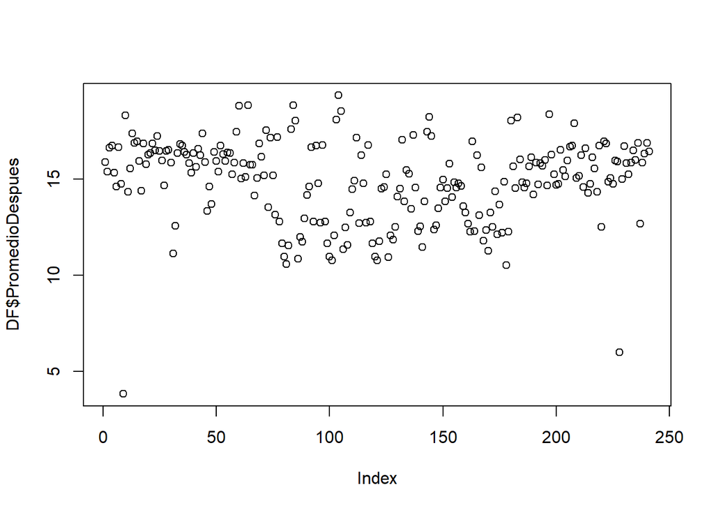

```r
plot(DF$PromedioDespues)
```

Los promedio fuera de nuestro rango de interés los clasificamos como NA para posteriormente ser eliminados. Esto fue considerando un promedio habitual de UTEC, por ejemplo, no se consideró el 20 como promedio.

```r
DF$PromedioDespues[DF$PromedioDespues<8] <-NA
DF$PromedioDespues[DF$PromedioDespues>19] <-NA
```

Hacemos lectura de los promedios después de adquirir el dispositivo tecnológico que más los ha ayudado en su desempeño académico, obteniendo el siguiente resumen definitivo:

-La media de promedio ponderado fue de 14.95.

-La promedio ponderado mínimo fue de 10.53 y el máximo fue de 18.85.

```r
summary(DF$PromedioDespues)
```

```
##    Min. 1st Qu.  Median    Mean 3rd Qu.    Max.    NA's
##   10.53   13.60   15.24   14.95   16.40   18.85       3
```

### Estudio días de la semana

```r
summary(DF$DiasSemanal)
```

```
##    Min. 1st Qu.  Median    Mean 3rd Qu.    Max.
##    1.00    5.00    6.00    5.66    7.00    8.00
```

Gráfico de dispersión de la cantidad de días a la semana dedidacos al estudio por parte de nuestros encuestados:

-Visualmente se puede apreciar que la mayor parte estudia entre 5 y 7 días.

-Se identifican valores ilógicos de 8 días, lo cual es absurdo porque la semana tiene 7 días

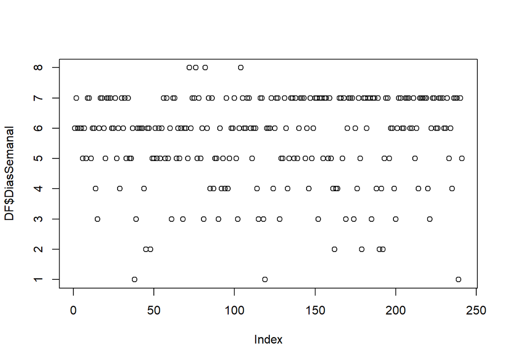

```r
plot(DF$DiasSemanal)
```

Los días de semana dedicados al estudio fuera de nuestro rango de interés los clasificamos como NA para posteriormente ser eliminados. Asimismo, eliminamos los valores absurdos, como el 8 días por semana.

```r
DF$DiasSemanal[DF$DiasSemanal<3] <-NA
DF$DiasSemanal[DF$DiasSemanal>7] <-NA
```

Hacemos lectura de los días que dedican al estudio, obteniendo el siguiente resumen definitivo:

-La promedio de días fue de 6.

```r
summary(DF$DiasSemanal)
```

```
##    Min. 1st Qu.  Median    Mean 3rd Qu.    Max.    NA's
##   3.000   5.000   6.000   5.776   7.000   7.000      13
```

Identificamos la cantidad total de nuestros NA, después de recategorizar los valores fuera de nuestro rango de interés y/o absurdos y/o no compatibles con nuestros fines:

```r
sum(is.na(DF))
```

```
## [1] 47
```

Se identifica la distribución de los nuevos NA’s por cada variable:

```r
na_por_variable <- colSums(is.na(DF))
print(na_por_variable)
```

```
##                Sexo                Edad        Ciclo_actual Recurso_Tecnologico
##                   0                   3                   0                   0
##        Dispositivos     Ciclo_adquirido              escala               curso
##                  13                   1                   2                   2
##         UsoHardware     Horas_semanales       PromedioAntes     PromedioDespues
##                   0                   9                   0                   3
##         UsoSoftware             carrera        aplicaciones         DiasSemanal
##                   1                   0                   0                  13
```

### Eliminamos las observaciones con NA’s para tener nuestra base de datos *limpia y prolija.*

```r
DF %>% na.omit(!complete.cases(DF)) -> DF1
```

## Descriptores Gráficos:

###Cantidad de encuestados, según género:

Nuestra base de datos registró 105 encuestados de género masculino y 95 de femenino.

```r
table(DF1$Sexo)
```

```
##
##  Femenino Masculino
##        95       105
```

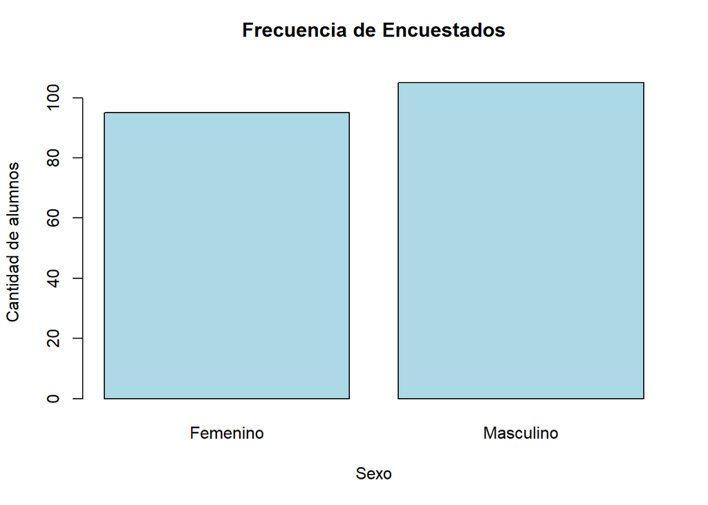

```r
frec<-table(DF1$Sexo)
barplot(frec, col="lightblue", ylab = "Cantidad de alumnos" , xlab = "Sexo",main="Frecuencia de Encuestados
        ")
```

###Frecuencia de los encuestados por edad:

La mayor parte de nuestros encuestados reportaron una edad de 20 años, seguido por 19 años. La minoría fue para los encuestados de 30 años-

```r
table(DF1$Edad)
```

```
##
## 16 17 18 19 20 21 22 23 26 30
##  5 19 35 41 56 23 14  5  1  1
```

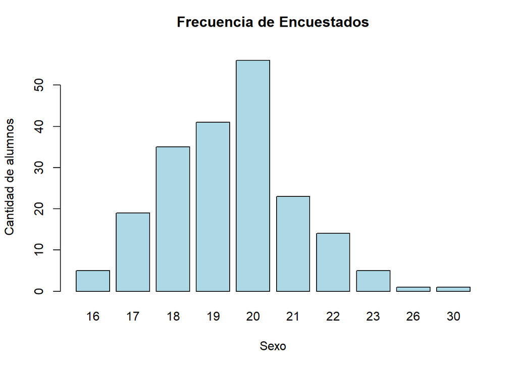

```r
frec<-table(DF1$Edad)
barplot(frec, col="lightblue", ylab = "Cantidad de alumnos" , xlab = "Sexo",main="Frecuencia de Encuestados
        ")
```

Diagrama de cajas y bigote para relacionar el Sexo y Edad:

-En el caso de las mujeres se pueden apreciar valores atípicos.

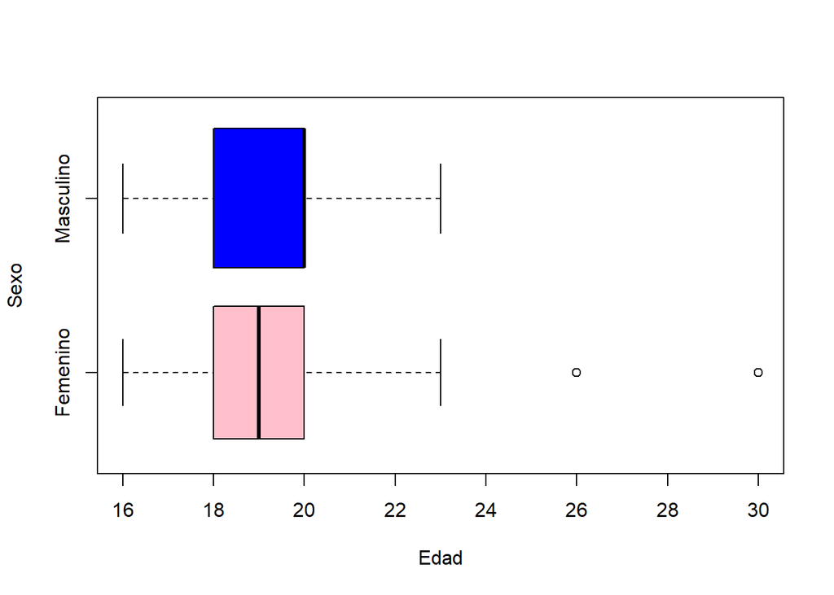

```r
grafico <-boxplot(Edad ~ Sexo,data=DF1, horizontal =T, varwidth = T, col=c("pink","blue"),xlab="Edad",ylab="Sexo")
```

El promedio de edad para los hombres es:

```r
promedio_masculinos <- mean(DF1$Edad[DF1$Sexo == "Masculino"])
print(promedio_masculinos)
```

```
## [1] 19.4
```

```r
promedio_femenino <- mean(DF1$Edad[DF1$Sexo == "Femenino"])
print(promedio_femenino)
```

```
## [1] 19.54737
```

¿Cuál es el promedio de la encuesta?

```r
round(mean(DF1$Edad),2)
```

```
## [1] 19.47
```

## Respondiendo a nuestros objetivos

###Software utilizado por estudiantes

Se realizó un análisis relacionando el sexo y el uso de los recursos tecnológicos de software en los alumnos de UTEC. Esto se plasmó en un diagrama de mosaico para representar ambas variables categóricas. En el gráfico se puede apreciar una ligera igualdad en el uso de softwares por ambos sexos, donde se evidencia un gran uso de software para fines académicos en los alumnos de UTEC.

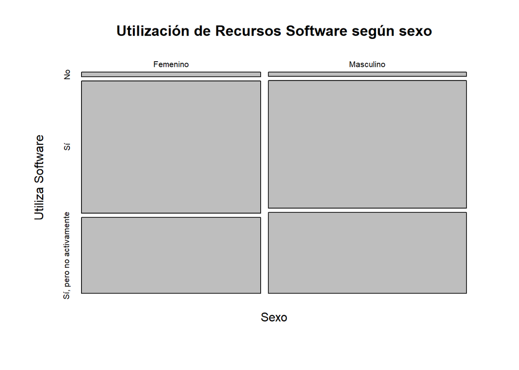

```r
mosaicplot(table(DF1$Sexo, DF1$UsoSoftware), shade = FALSE, main = "Utilización de Recursos Software según sexo",
           xlab = "Sexo", ylab = "Utiliza Software")
```

### Hardware usado por los estudiantes

Se realizó un análisis relacionando el sexo y el uso de los recursos tecnológicos de hardware en los alumnos de UTEC. Esto se plasmó en un diagrama de mosaico para representar ambas variables categóricas. En el gráfico se puede apreciar una ligera igualdad en el uso de softwares por ambos sexos, sin embargo hay una ligera superioridad por no usar herramientas de hardware en el género masculino.

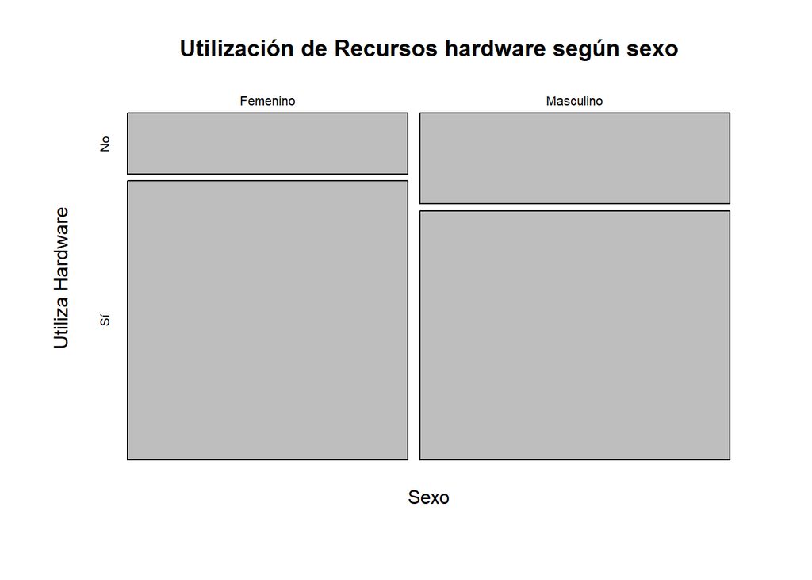

```r
mosaicplot(table(DF1$Sexo, DF1$UsoHardware), shade = FALSE, main = "Utilización de Recursos hardware según sexo",xlab = "Sexo", ylab = "Utiliza Hardware")
```

### Uso de hardwares por parte de los estudiantes de Utec

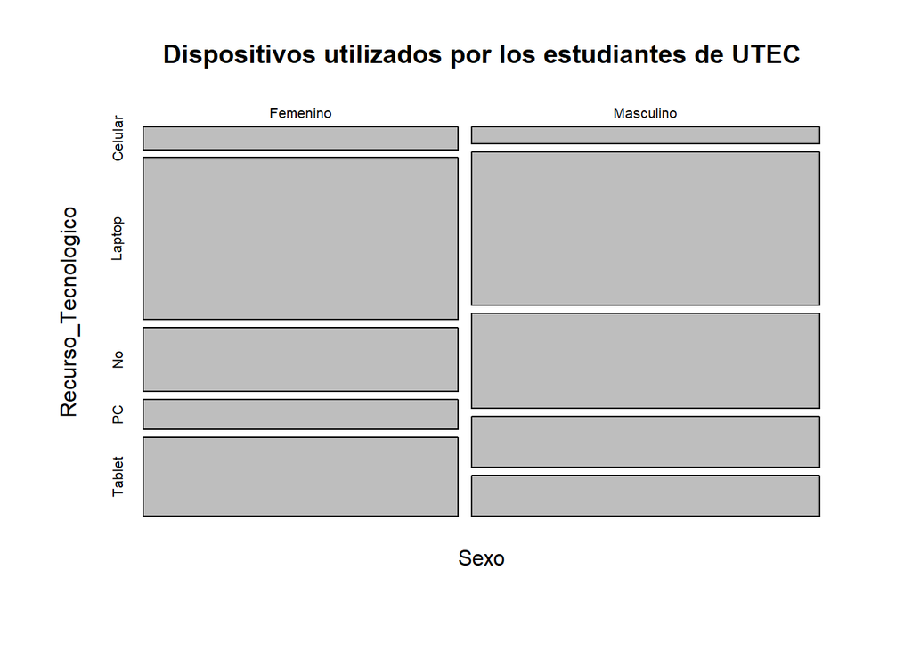

```r
DF1 %>% mutate(Recurso_Tecnologico =
        ifelse(Recurso_Tecnologico == "No uso activamente recursos tecnologicos con fines académicos","No",
        ifelse(Recurso_Tecnologico == "Computadora","PC",
               Recurso_Tecnologico
))) -> DFN

mosaicplot(table(DFN$Sexo, DFN$Recurso_Tecnologico), shade = FALSE, main = "Dispositivos utilizados por los estudiantes de UTEC",
           xlab = "Sexo", ylab = "Recurso_Tecnologico")
```

### Productividad académica y el uso de recursos tecnológicos de Hardware

Realizamos el siguiente análisis, para visualizar de que tan útil son los recursos tecnológicos para un mayor rendimiento académico

Creamos un dataframe con solo los que usan hardware, con información adicional con el promedio antes y después, sexo y ciclo para visualizar su progreso académico

```r
datos10 <- DF1 %>% filter(DF1$UsoHardware == "Sí") %>% select("PromedioDespues","PromedioAntes","Sexo","Ciclo_actual")
```

Restamos el promedio después con el antes, paa notar si hay un progreso de adición o reducción

```r
datos10 <- cbind(datos10, "Diferencia de promedios" = datos10$PromedioDespues-datos10$PromedioAntes)
#View(DFT)
```

Realizamos el gráfico por SEXO con el progreso académico

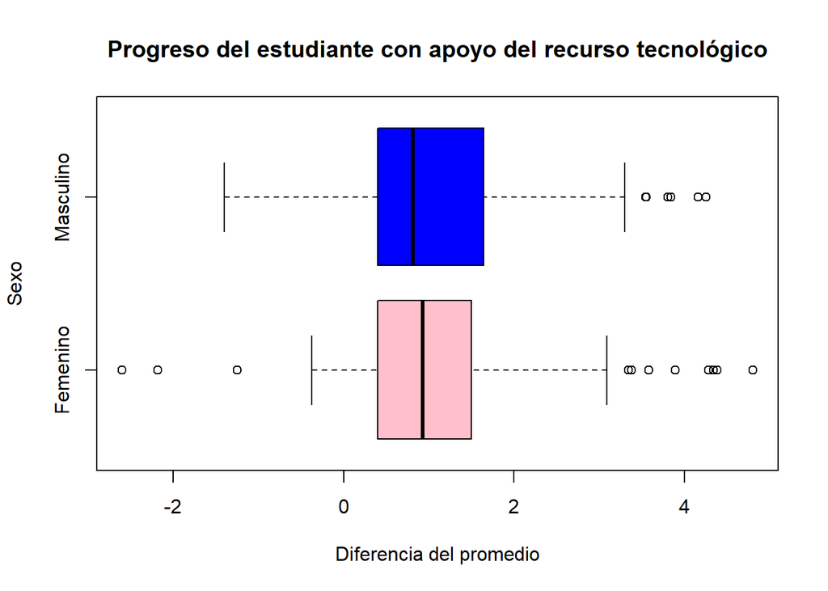

```r
boxplot(datos10$`Diferencia de promedios` ~ datos10$Sexo, horizontal =T, varwidth = T, col=c("pink","blue"),xlab="Diferencia del promedio",ylab="Sexo",main="Progreso del estudiante con apoyo del recurso tecnológico")
```

Ahora realizamos una relación de progreso y CICLO, lo realizamos de manera vertical para una mejor vista

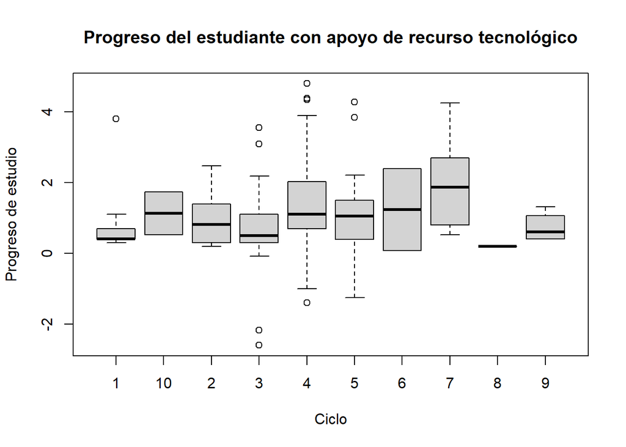

```r
boxplot(datos10$`Diferencia de promedios`~datos10$Ciclo_actual,
        xlab="Ciclo",ylab="Progreso de estudio",main="Progreso del estudiante con apoyo de recurso tecnológico")
```

#### ¿Los estudiantes de UTEC recomiendan la utilización de los recursos tecnológicos?

Realizamos un mapa de calor para saber la opinión de los estudiantes de Utec sobre si debemos utilizar los recursos tecnológicos para nuestras actividades académicas

```r
#una relación de la escala con el ciclo
DESEO <- DF1$escala;
CICLO <- factor(DF1$Ciclo_actual, levels = c("1","2","3","4","5","6","7","8","9","10"))
#usamos factor para ordenar
freq <- table(DESEO,CICLO)
df_frequencias <- as.data.frame(freq)
```

Realizamos un mapa de calor , para una mejor vista de la puntuación que ponen para utilizar recursos tecnológicos

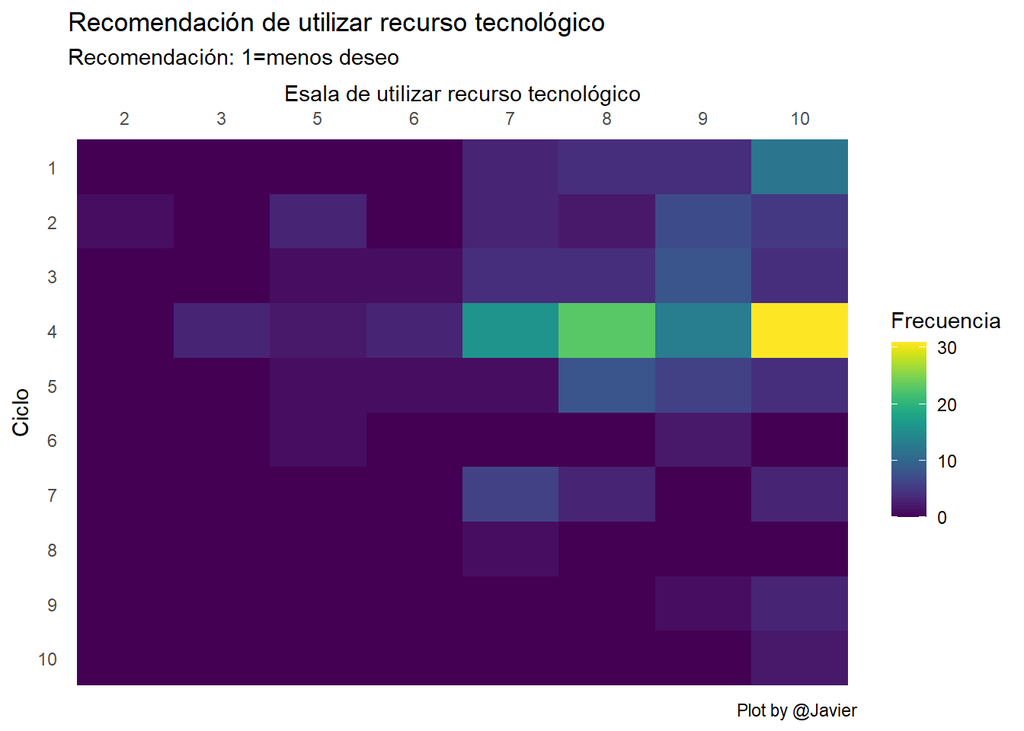

```r
ggplot(df_frequencias,aes(DESEO,CICLO, fill =Freq))+
  scale_fill_viridis()+
  geom_bin2d()+
  scale_x_discrete(name="Esala de utilizar recurso tecnológico",
                   position ="top")+
  scale_y_discrete(name="Ciclo",
                   limits = rev(levels(CICLO)))+
  labs(title="Recomendación de utilizar recurso tecnológico",
       subtitle="Recomendación: 1=menos deseo",
       caption= "Plot by @Javier", fill= "Frecuencia")+
  theme_minimal()+
  theme(panel.grid.major= element_blank(),
        panel.grid.minor = element_blank())
```